# Risk Factor Analysis

## Outcome Variable

**Outcome Variable:** y_rate_haz

## Predictor Variables

**Intervention Variable:** safeh20

**Adjustment Set:**

- arm
- sex
- W_mage
- meducyrs
- feducyrs
- hhwealth_quart
- hfoodsec
- W_mhtcm
- W_nrooms
- W_nchldlt5
- W_parity
- impfloor
- impsan
- delta_W_mage
- delta_meducyrs
- delta_feducyrs
- delta_hhwealth_quart
- delta_hfoodsec
- delta_W_mhtcm
- delta_W_nrooms
- delta_W_nchldlt5
- delta_W_parity
- delta_impfloor
- delta_impsan

## Stratifying Variables

The analysis was stratified on these variable(s):

- agecat
- studyid
- country

## Data Summary

| agecat | studyid | country | safeh20 | n_cell | n |
| --- | --- | --- | --- | --- | --- |
| 0-3 months | ki0047075b-MAL-ED | BANGLADESH | 0 | 237 | 237 |
| 0-3 months | ki1017093-NIH-Birth | BANGLADESH | 0 | 2 | 566 |
| 0-3 months | ki1017093-NIH-Birth | BANGLADESH | 1 | 564 | 566 |
| 0-3 months | ki1017093b-PROVIDE | BANGLADESH | 1 | 634 | 634 |
| 0-3 months | ki1017093c-NIH-Crypto | BANGLADESH | 1 | 720 | 720 |
| 0-3 months | kiGH5241-JiVitA-3 | BANGLADESH | 0 | 35 | 20029 |
| 0-3 months | kiGH5241-JiVitA-3 | BANGLADESH | 1 | 19994 | 20029 |
| 0-3 months | kiGH5241-JiVitA-4 | BANGLADESH | 1 | 1805 | 1805 |
| 0-3 months | ki0047075b-MAL-ED | BRAZIL | 0 | 124 | 124 |
| 0-3 months | ki0047075b-MAL-ED | INDIA | 0 | 194 | 194 |
| 0-3 months | ki0047075b-MAL-ED | NEPAL | 0 | 170 | 171 |
| 0-3 months | ki0047075b-MAL-ED | NEPAL | 1 | 1 | 171 |
| 0-3 months | ki0047075b-MAL-ED | PERU | 0 | 238 | 249 |
| 0-3 months | ki0047075b-MAL-ED | PERU | 1 | 11 | 249 |
| 0-3 months | ki1114097-CONTENT | PERU | 0 | 1 | 6 |
| 0-3 months | ki1114097-CONTENT | PERU | 1 | 5 | 6 |
| 0-3 months | ki0047075b-MAL-ED | SOUTH AFRICA | 0 | 180 | 213 |
| 0-3 months | ki0047075b-MAL-ED | SOUTH AFRICA | 1 | 33 | 213 |
| 0-3 months | ki0047075b-MAL-ED | TANZANIA, UNITED REPUBLIC OF | 0 | 70 | 225 |
| 0-3 months | ki0047075b-MAL-ED | TANZANIA, UNITED REPUBLIC OF | 1 | 155 | 225 |
| 3-6 months | ki0047075b-MAL-ED | BANGLADESH | 0 | 231 | 231 |
| 3-6 months | ki1017093-NIH-Birth | BANGLADESH | 0 | 2 | 523 |
| 3-6 months | ki1017093-NIH-Birth | BANGLADESH | 1 | 521 | 523 |
| 3-6 months | ki1017093b-PROVIDE | BANGLADESH | 1 | 572 | 572 |
| 3-6 months | ki1017093c-NIH-Crypto | BANGLADESH | 1 | 695 | 695 |
| 3-6 months | kiGH5241-JiVitA-3 | BANGLADESH | 0 | 12 | 12573 |
| 3-6 months | kiGH5241-JiVitA-3 | BANGLADESH | 1 | 12561 | 12573 |
| 3-6 months | kiGH5241-JiVitA-4 | BANGLADESH | 1 | 1839 | 1839 |
| 3-6 months | ki0047075b-MAL-ED | BRAZIL | 0 | 141 | 141 |
| 3-6 months | ki0047075b-MAL-ED | INDIA | 0 | 229 | 229 |

[output cut: 55 more lines]

The following strata were considered:

- agecat: 0-3 months, studyid: ki0047075b-MAL-ED, country: BANGLADESH
- agecat: 0-3 months, studyid: ki0047075b-MAL-ED, country: BRAZIL
- agecat: 0-3 months, studyid: ki0047075b-MAL-ED, country: INDIA
- agecat: 0-3 months, studyid: ki0047075b-MAL-ED, country: NEPAL
- agecat: 0-3 months, studyid: ki0047075b-MAL-ED, country: PERU
- agecat: 0-3 months, studyid: ki0047075b-MAL-ED, country: SOUTH AFRICA
- agecat: 0-3 months, studyid: ki0047075b-MAL-ED, country: TANZANIA, UNITED REPUBLIC OF
- agecat: 0-3 months, studyid: ki1017093-NIH-Birth, country: BANGLADESH
- agecat: 0-3 months, studyid: ki1017093b-PROVIDE, country: BANGLADESH
- agecat: 0-3 months, studyid: ki1017093c-NIH-Crypto, country: BANGLADESH
- agecat: 0-3 months, studyid: ki1114097-CONTENT, country: PERU
- agecat: 0-3 months, studyid: kiGH5241-JiVitA-3, country: BANGLADESH
- agecat: 0-3 months, studyid: kiGH5241-JiVitA-4, country: BANGLADESH
- agecat: 12-24 months, studyid: ki0047075b-MAL-ED, country: BANGLADESH
- agecat: 12-24 months, studyid: ki0047075b-MAL-ED, country: BRAZIL
- agecat: 12-24 months, studyid: ki0047075b-MAL-ED, country: INDIA
- agecat: 12-24 months, studyid: ki0047075b-MAL-ED, country: NEPAL
- agecat: 12-24 months, studyid: ki0047075b-MAL-ED, country: PERU
- agecat: 12-24 months, studyid: ki0047075b-MAL-ED, country: SOUTH AFRICA
- agecat: 12-24 months, studyid: ki0047075b-MAL-ED, country: TANZANIA, UNITED REPUBLIC OF
- agecat: 12-24 months, studyid: ki1017093-NIH-Birth, country: BANGLADESH
- agecat: 12-24 months, studyid: ki1017093b-PROVIDE, country: BANGLADESH
- agecat: 12-24 months, studyid: ki1017093c-NIH-Crypto, country: BANGLADESH
- agecat: 12-24 months, studyid: ki1114097-CONTENT, country: PERU
- agecat: 12-24 months, studyid: ki1148112-LCNI-5, country: MALAWI
- agecat: 12-24 months, studyid: kiGH5241-JiVitA-3, country: BANGLADESH
- agecat: 12-24 months, studyid: kiGH5241-JiVitA-4, country: BANGLADESH
- agecat: 3-6 months, studyid: ki0047075b-MAL-ED, country: BANGLADESH
- agecat: 3-6 months, studyid: ki0047075b-MAL-ED, country: BRAZIL
- agecat: 3-6 months, studyid: ki0047075b-MAL-ED, country: INDIA
- agecat: 3-6 months, studyid: ki0047075b-MAL-ED, country: NEPAL
- agecat: 3-6 months, studyid: ki0047075b-MAL-ED, country: PERU
- agecat: 3-6 months, studyid: ki0047075b-MAL-ED, country: SOUTH AFRICA
- agecat: 3-6 months, studyid: ki0047075b-MAL-ED, country: TANZANIA, UNITED REPUBLIC OF
- agecat: 3-6 months, studyid: ki1017093-NIH-Birth, country: BANGLADESH
- agecat: 3-6 months, studyid: ki1017093b-PROVIDE, country: BANGLADESH
- agecat: 3-6 months, studyid: ki1017093c-NIH-Crypto, country: BANGLADESH
- agecat: 3-6 months, studyid: ki1114097-CONTENT, country: PERU
- agecat: 3-6 months, studyid: kiGH5241-JiVitA-3, country: BANGLADESH
- agecat: 3-6 months, studyid: kiGH5241-JiVitA-4, country: BANGLADESH
- agecat: 6-12 months, studyid: ki0047075b-MAL-ED, country: BANGLADESH
- agecat: 6-12 months, studyid: ki0047075b-MAL-ED, country: BRAZIL
- agecat: 6-12 months, studyid: ki0047075b-MAL-ED, country: INDIA
- agecat: 6-12 months, studyid: ki0047075b-MAL-ED, country: NEPAL
- agecat: 6-12 months, studyid: ki0047075b-MAL-ED, country: PERU
- agecat: 6-12 months, studyid: ki0047075b-MAL-ED, country: SOUTH AFRICA
- agecat: 6-12 months, studyid: ki0047075b-MAL-ED, country: TANZANIA, UNITED REPUBLIC OF
- agecat: 6-12 months, studyid: ki1000304b-SAS-FoodSuppl, country: INDIA
- agecat: 6-12 months, studyid: ki1017093-NIH-Birth, country: BANGLADESH
- agecat: 6-12 months, studyid: ki1017093b-PROVIDE, country: BANGLADESH
- agecat: 6-12 months, studyid: ki1017093c-NIH-Crypto, country: BANGLADESH
- agecat: 6-12 months, studyid: ki1114097-CONTENT, country: PERU
- agecat: 6-12 months, studyid: ki1148112-LCNI-5, country: MALAWI
- agecat: 6-12 months, studyid: kiGH5241-JiVitA-3, country: BANGLADESH
- agecat: 6-12 months, studyid: kiGH5241-JiVitA-4, country: BANGLADESH

### Dropped Strata

Some strata were dropped due to rare outcomes:

- agecat: 0-3 months, studyid: ki1017093-NIH-Birth, country: BANGLADESH
- agecat: 0-3 months, studyid: ki0047075b-MAL-ED, country: NEPAL
- agecat: 0-3 months, studyid: ki1114097-CONTENT, country: PERU
- agecat: 3-6 months, studyid: ki1017093-NIH-Birth, country: BANGLADESH
- agecat: 3-6 months, studyid: ki0047075b-MAL-ED, country: NEPAL
- agecat: 3-6 months, studyid: ki1114097-CONTENT, country: PERU
- agecat: 6-12 months, studyid: ki1017093-NIH-Birth, country: BANGLADESH
- agecat: 6-12 months, studyid: ki0047075b-MAL-ED, country: NEPAL
- agecat: 6-12 months, studyid: ki1114097-CONTENT, country: PERU
- agecat: 12-24 months, studyid: ki1017093-NIH-Birth, country: BANGLADESH
- agecat: 12-24 months, studyid: ki0047075b-MAL-ED, country: NEPAL
- agecat: 12-24 months, studyid: ki1114097-CONTENT, country: PERU

## Methods Detail

We’re interested in the causal parameters $E[Y_a]$ for all values of $a \in \mathcal{A}$. These parameters represent the mean outcome if, possibly contrary to fact, we intervened to set all units to have $A=a$. Under the randomization and positivity assumptions, these are identified by the statistical parameters $\psi_a=E_W[E_{Y|A,W}(Y|A=a,W)]$. In addition, we’re interested in the mean of $Y$, $E[Y]$ under no intervention (the observed mean). We will estimate these parameters by using SuperLearner to fit the relevant likelihood factors – $E_{Y|A,W}(Y|A=a,W)$ and $p(A=a|W)$, and then updating our likelihood fit using a joint TMLE.

For unadjusted analyses ($W=\{\}$), initial likelihoods were estimated using Lrnr_glm to estimate the simple $E(Y|A)$ and Lrnr_mean to estimate $p(A)$. For adjusted analyses, a small library containing Lrnr_glmnet, Lrnr_xgboost, and Lrnr_mean was used.

[output not shown]

[output cut: 18485 more lines]

[output not shown]

# Results Detail

## Results Plots

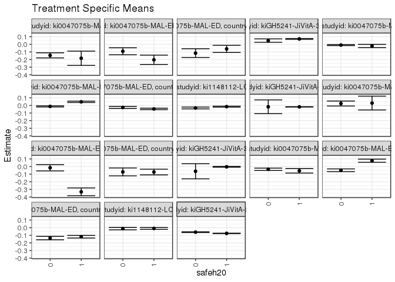

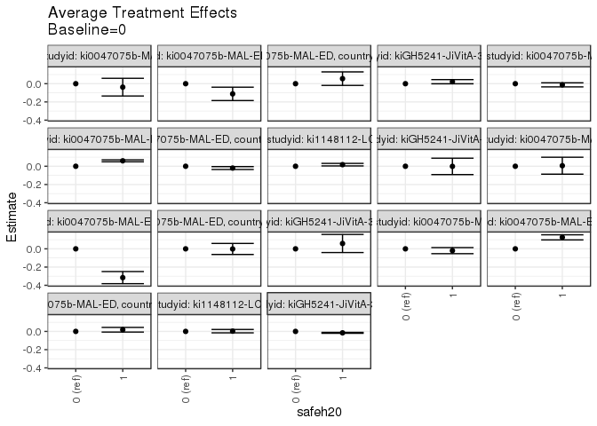

## Results Table

### Parameter: TSM

| agecat | studyid | country | intervention_level | baseline_level | estimate | ci_lower | ci_upper |
| --- | --- | --- | --- | --- | --- | --- | --- |
| 0-3 months | ki0047075b-MAL-ED | PERU | 0 | NA | -0.1451539 | -0.1788071 | -0.1115008 |
| 0-3 months | ki0047075b-MAL-ED | PERU | 1 | NA | -0.1831437 | -0.2767493 | -0.0895380 |
| 0-3 months | ki0047075b-MAL-ED | SOUTH AFRICA | 0 | NA | -0.0915897 | -0.1375464 | -0.0456329 |
| 0-3 months | ki0047075b-MAL-ED | SOUTH AFRICA | 1 | NA | -0.2032429 | -0.2644254 | -0.1420604 |
| 0-3 months | ki0047075b-MAL-ED | TANZANIA, UNITED REPUBLIC OF | 0 | NA | -0.1157602 | -0.1729647 | -0.0585557 |
| 0-3 months | ki0047075b-MAL-ED | TANZANIA, UNITED REPUBLIC OF | 1 | NA | -0.0603618 | -0.1071273 | -0.0135964 |
| 0-3 months | kiGH5241-JiVitA-3 | BANGLADESH | 0 | NA | 0.0486812 | 0.0260438 | 0.0713186 |
| 0-3 months | kiGH5241-JiVitA-3 | BANGLADESH | 1 | NA | 0.0706399 | 0.0656789 | 0.0756009 |
| 3-6 months | ki0047075b-MAL-ED | PERU | 0 | NA | 0.0250955 | -0.0073790 | 0.0575699 |
| 3-6 months | ki0047075b-MAL-ED | PERU | 1 | NA | 0.0311812 | -0.0598632 | 0.1222257 |
| 3-6 months | ki0047075b-MAL-ED | SOUTH AFRICA | 0 | NA | -0.0163093 | -0.0570204 | 0.0244019 |
| 3-6 months | ki0047075b-MAL-ED | SOUTH AFRICA | 1 | NA | -0.3320575 | -0.3831211 | -0.2809938 |
| 3-6 months | ki0047075b-MAL-ED | TANZANIA, UNITED REPUBLIC OF | 0 | NA | -0.0703930 | -0.1223926 | -0.0183934 |
| 3-6 months | ki0047075b-MAL-ED | TANZANIA, UNITED REPUBLIC OF | 1 | NA | -0.0717865 | -0.1092371 | -0.0343358 |
| 3-6 months | kiGH5241-JiVitA-3 | BANGLADESH | 0 | NA | -0.0619592 | -0.1615036 | 0.0375853 |
| 3-6 months | kiGH5241-JiVitA-3 | BANGLADESH | 1 | NA | -0.0033843 | -0.0082477 | 0.0014790 |
| 6-12 months | ki0047075b-MAL-ED | PERU | 0 | NA | -0.0357437 | -0.0507991 | -0.0206882 |
| 6-12 months | ki0047075b-MAL-ED | PERU | 1 | NA | -0.0552980 | -0.0851806 | -0.0254155 |
| 6-12 months | ki0047075b-MAL-ED | SOUTH AFRICA | 0 | NA | -0.0490168 | -0.0672591 | -0.0307745 |
| 6-12 months | ki0047075b-MAL-ED | SOUTH AFRICA | 1 | NA | 0.0769873 | 0.0559826 | 0.0979920 |
| 6-12 months | ki0047075b-MAL-ED | TANZANIA, UNITED REPUBLIC OF | 0 | NA | -0.1368305 | -0.1594332 | -0.1142277 |
| 6-12 months | ki0047075b-MAL-ED | TANZANIA, UNITED REPUBLIC OF | 1 | NA | -0.1184856 | -0.1360437 | -0.1009274 |
| 6-12 months | ki1148112-LCNI-5 | MALAWI | 0 | NA | -0.0125986 | -0.0283461 | 0.0031488 |
| 6-12 months | ki1148112-LCNI-5 | MALAWI | 1 | NA | -0.0098210 | -0.0219204 | 0.0022785 |
| 6-12 months | kiGH5241-JiVitA-3 | BANGLADESH | 0 | NA | -0.0590814 | -0.0634345 | -0.0547284 |
| 6-12 months | kiGH5241-JiVitA-3 | BANGLADESH | 1 | NA | -0.0749197 | -0.0777658 | -0.0720736 |
| 12-24 months | ki0047075b-MAL-ED | PERU | 0 | NA | -0.0094953 | -0.0169221 | -0.0020686 |
| 12-24 months | ki0047075b-MAL-ED | PERU | 1 | NA | -0.0219419 | -0.0430499 | -0.0008339 |
| 12-24 months | ki0047075b-MAL-ED | SOUTH AFRICA | 0 | NA | -0.0126614 | -0.0204152 | -0.0049077 |
| 12-24 months | ki0047075b-MAL-ED | SOUTH AFRICA | 1 | NA | 0.0471995 | 0.0382983 | 0.0561007 |
| 12-24 months | ki0047075b-MAL-ED | TANZANIA, UNITED REPUBLIC OF | 0 | NA | -0.0263586 | -0.0391788 | -0.0135383 |
| 12-24 months | ki0047075b-MAL-ED | TANZANIA, UNITED REPUBLIC OF | 1 | NA | -0.0459731 | -0.0553586 | -0.0365875 |
| 12-24 months | ki1148112-LCNI-5 | MALAWI | 0 | NA | -0.0335538 | -0.0457664 | -0.0213412 |
| 12-24 months | ki1148112-LCNI-5 | MALAWI | 1 | NA | -0.0159821 | -0.0224201 | -0.0095440 |
| 12-24 months | kiGH5241-JiVitA-3 | BANGLADESH | 0 | NA | -0.0175328 | -0.1077581 | 0.0726924 |
| 12-24 months | kiGH5241-JiVitA-3 | BANGLADESH | 1 | NA | -0.0187806 | -0.0206213 | -0.0169399 |

### Parameter: E(Y)

| agecat | studyid | country | intervention_level | baseline_level | estimate | ci_lower | ci_upper |
| --- | --- | --- | --- | --- | --- | --- | --- |
| 0-3 months | ki0047075b-MAL-ED | PERU | NA | NA | -0.1468292 | -0.1796215 | -0.1140369 |
| 0-3 months | ki0047075b-MAL-ED | SOUTH AFRICA | NA | NA | -0.1094143 | -0.1554047 | -0.0634239 |
| 0-3 months | ki0047075b-MAL-ED | TANZANIA, UNITED REPUBLIC OF | NA | NA | -0.0482527 | -0.0869775 | -0.0095280 |
| 0-3 months | kiGH5241-JiVitA-3 | BANGLADESH | NA | NA | 0.0705622 | 0.0656080 | 0.0755165 |
| 3-6 months | ki0047075b-MAL-ED | PERU | NA | NA | 0.0253395 | -0.0065080 | 0.0571869 |
| 3-6 months | ki0047075b-MAL-ED | SOUTH AFRICA | NA | NA | 0.0016172 | -0.0365482 | 0.0397826 |
| 3-6 months | ki0047075b-MAL-ED | TANZANIA, UNITED REPUBLIC OF | NA | NA | -0.0714664 | -0.1037306 | -0.0392021 |
| 3-6 months | kiGH5241-JiVitA-3 | BANGLADESH | NA | NA | -0.0034446 | -0.0083108 | 0.0014217 |
| 6-12 months | ki0047075b-MAL-ED | PERU | NA | NA | -0.0365155 | -0.0510332 | -0.0219979 |
| 6-12 months | ki0047075b-MAL-ED | SOUTH AFRICA | NA | NA | -0.0537261 | -0.0711424 | -0.0363097 |
| 6-12 months | ki0047075b-MAL-ED | TANZANIA, UNITED REPUBLIC OF | NA | NA | -0.1243581 | -0.1400706 | -0.1086456 |
| 6-12 months | ki1148112-LCNI-5 | MALAWI | NA | NA | -0.0067938 | -0.0177737 | 0.0041862 |
| 6-12 months | kiGH5241-JiVitA-3 | BANGLADESH | NA | NA | -0.0748465 | -0.0776904 | -0.0720026 |
| 12-24 months | ki0047075b-MAL-ED | PERU | NA | NA | -0.0099718 | -0.0171682 | -0.0027754 |
| 12-24 months | ki0047075b-MAL-ED | SOUTH AFRICA | NA | NA | -0.0155353 | -0.0231357 | -0.0079349 |
| 12-24 months | ki0047075b-MAL-ED | TANZANIA, UNITED REPUBLIC OF | NA | NA | -0.0398784 | -0.0476581 | -0.0320988 |
| 12-24 months | ki1148112-LCNI-5 | MALAWI | NA | NA | -0.0160605 | -0.0218715 | -0.0102495 |
| 12-24 months | kiGH5241-JiVitA-3 | BANGLADESH | NA | NA | -0.0187787 | -0.0206287 | -0.0169287 |

### Parameter: ATE

| agecat | studyid | country | intervention_level | baseline_level | estimate | ci_lower | ci_upper |
| --- | --- | --- | --- | --- | --- | --- | --- |
| 0-3 months | ki0047075b-MAL-ED | PERU | 0 | 0 | 0.0000000 | 0.0000000 | 0.0000000 |
| 0-3 months | ki0047075b-MAL-ED | PERU | 1 | 0 | -0.0379897 | -0.1349126 | 0.0589331 |
| 0-3 months | ki0047075b-MAL-ED | SOUTH AFRICA | 0 | 0 | 0.0000000 | 0.0000000 | 0.0000000 |
| 0-3 months | ki0047075b-MAL-ED | SOUTH AFRICA | 1 | 0 | -0.1116532 | -0.1851234 | -0.0381830 |
| 0-3 months | ki0047075b-MAL-ED | TANZANIA, UNITED REPUBLIC OF | 0 | 0 | 0.0000000 | 0.0000000 | 0.0000000 |
| 0-3 months | ki0047075b-MAL-ED | TANZANIA, UNITED REPUBLIC OF | 1 | 0 | 0.0553984 | -0.0186246 | 0.1294213 |
| 0-3 months | kiGH5241-JiVitA-3 | BANGLADESH | 0 | 0 | 0.0000000 | 0.0000000 | 0.0000000 |
| 0-3 months | kiGH5241-JiVitA-3 | BANGLADESH | 1 | 0 | 0.0219587 | -0.0008981 | 0.0448155 |
| 3-6 months | ki0047075b-MAL-ED | PERU | 0 | 0 | 0.0000000 | 0.0000000 | 0.0000000 |
| 3-6 months | ki0047075b-MAL-ED | PERU | 1 | 0 | 0.0060858 | -0.0867798 | 0.0989514 |
| 3-6 months | ki0047075b-MAL-ED | SOUTH AFRICA | 0 | 0 | 0.0000000 | 0.0000000 | 0.0000000 |
| 3-6 months | ki0047075b-MAL-ED | SOUTH AFRICA | 1 | 0 | -0.3157482 | -0.3822987 | -0.2491978 |
| 3-6 months | ki0047075b-MAL-ED | TANZANIA, UNITED REPUBLIC OF | 0 | 0 | 0.0000000 | 0.0000000 | 0.0000000 |
| 3-6 months | ki0047075b-MAL-ED | TANZANIA, UNITED REPUBLIC OF | 1 | 0 | -0.0013935 | -0.0618531 | 0.0590661 |
| 3-6 months | kiGH5241-JiVitA-3 | BANGLADESH | 0 | 0 | 0.0000000 | 0.0000000 | 0.0000000 |
| 3-6 months | kiGH5241-JiVitA-3 | BANGLADESH | 1 | 0 | 0.0585749 | -0.0407457 | 0.1578954 |
| 6-12 months | ki0047075b-MAL-ED | PERU | 0 | 0 | 0.0000000 | 0.0000000 | 0.0000000 |
| 6-12 months | ki0047075b-MAL-ED | PERU | 1 | 0 | -0.0195544 | -0.0530153 | 0.0139065 |
| 6-12 months | ki0047075b-MAL-ED | SOUTH AFRICA | 0 | 0 | 0.0000000 | 0.0000000 | 0.0000000 |
| 6-12 months | ki0047075b-MAL-ED | SOUTH AFRICA | 1 | 0 | 0.1260041 | 0.0982601 | 0.1537481 |
| 6-12 months | ki0047075b-MAL-ED | TANZANIA, UNITED REPUBLIC OF | 0 | 0 | 0.0000000 | 0.0000000 | 0.0000000 |
| 6-12 months | ki0047075b-MAL-ED | TANZANIA, UNITED REPUBLIC OF | 1 | 0 | 0.0183449 | -0.0072505 | 0.0439403 |
| 6-12 months | ki1148112-LCNI-5 | MALAWI | 0 | 0 | 0.0000000 | 0.0000000 | 0.0000000 |
| 6-12 months | ki1148112-LCNI-5 | MALAWI | 1 | 0 | 0.0027777 | -0.0157913 | 0.0213467 |
| 6-12 months | kiGH5241-JiVitA-3 | BANGLADESH | 0 | 0 | 0.0000000 | 0.0000000 | 0.0000000 |
| 6-12 months | kiGH5241-JiVitA-3 | BANGLADESH | 1 | 0 | -0.0158383 | -0.0209183 | -0.0107582 |
| 12-24 months | ki0047075b-MAL-ED | PERU | 0 | 0 | 0.0000000 | 0.0000000 | 0.0000000 |
| 12-24 months | ki0047075b-MAL-ED | PERU | 1 | 0 | -0.0124466 | -0.0348393 | 0.0099462 |
| 12-24 months | ki0047075b-MAL-ED | SOUTH AFRICA | 0 | 0 | 0.0000000 | 0.0000000 | 0.0000000 |
| 12-24 months | ki0047075b-MAL-ED | SOUTH AFRICA | 1 | 0 | 0.0598609 | 0.0492159 | 0.0705060 |
| 12-24 months | ki0047075b-MAL-ED | TANZANIA, UNITED REPUBLIC OF | 0 | 0 | 0.0000000 | 0.0000000 | 0.0000000 |
| 12-24 months | ki0047075b-MAL-ED | TANZANIA, UNITED REPUBLIC OF | 1 | 0 | -0.0196145 | -0.0353358 | -0.0038932 |
| 12-24 months | ki1148112-LCNI-5 | MALAWI | 0 | 0 | 0.0000000 | 0.0000000 | 0.0000000 |
| 12-24 months | ki1148112-LCNI-5 | MALAWI | 1 | 0 | 0.0175717 | 0.0037632 | 0.0313802 |
| 12-24 months | kiGH5241-JiVitA-3 | BANGLADESH | 0 | 0 | 0.0000000 | 0.0000000 | 0.0000000 |
| 12-24 months | kiGH5241-JiVitA-3 | BANGLADESH | 1 | 0 | -0.0012478 | -0.0913942 | 0.0888987 |